# wk10

zimeng

2019/3/21

```r
dataset <- read.csv(file = "https://raw.githubusercontent.com/OscarFHC/EAS538_2018/master/Week10_ANCOVA/sanddata.csv", sep = ",", header = T,comment.char = "#")
```

```r
head(dataset)
```

```
##   juveniles     sand temperature  rainfall humanpop country
## 1  1450.489 348.7163    27.84830  907.7776 666.8436   China
## 2  1306.366 766.6340    27.02602 1280.4317 780.5680   China
## 3  1900.798 431.7617    24.70595 1430.2775 441.4950   China
## 4  1919.895 475.4157    25.69920 2227.2813 758.7727   China
## 5  1004.545 595.7553    24.47535 1424.5315 541.2254   China
## 6  1681.178 485.7410    24.20445 1129.9629 396.2639   China
```

```r
cor(dataset[,-6],dataset[,-6])
```

```
##               juveniles        sand  temperature    rainfall     humanpop
## juveniles    1.00000000 -0.40060237 -0.287562662  0.13030061 -0.093874549
## sand        -0.40060237  1.00000000  0.278387847 -0.10758403  0.040841125
## temperature -0.28756266  0.27838785  1.000000000 -0.40000000  0.008017561
## rainfall     0.13030061 -0.10758403 -0.400000000  1.00000000  0.022808524
## humanpop    -0.09387455  0.04084112  0.008017561  0.02280852  1.000000000
```

```r
linmod <- lm(juveniles ~ sand + temperature + rainfall + humanpop + country, data = dataset)
```

```r
summary(linmod)
```

```
##
## Call:
## lm(formula = juveniles ~ sand + temperature + rainfall + humanpop +
##     country, data = dataset)
##
## Residuals:
##      Min       1Q   Median       3Q      Max
## -1991.38  -393.25    21.99   389.21  1766.18
##
## Coefficients:
##                    Estimate Std. Error t value Pr(>|t|)
## (Intercept)      4603.65570  374.53180  12.292  < 2e-16 ***
## sand               -1.51796    0.13221 -11.481  < 2e-16 ***
## temperature       -76.81031   13.51391  -5.684 1.73e-08 ***
## rainfall            0.04423    0.05576   0.793 0.427860
## humanpop           -0.39505    0.14076  -2.807 0.005104 **
## countryIndia      -33.74344   53.20575  -0.634 0.526092
## countryIndonesia  -46.85508   53.30556  -0.879 0.379619
## countryMalaysia  -190.48339   53.30196  -3.574 0.000369 ***
## ---
## Signif. codes:  0 '***' 0.001 '**' 0.01 '*' 0.05 '.' 0.1 ' ' 1
##
## Residual standard error: 594.7 on 992 degrees of freedom
## Multiple R-squared:  0.2125, Adjusted R-squared:  0.2069
## F-statistic: 38.24 on 7 and 992 DF,  p-value: < 2.2e-16
```

```r
table(dataset$country)
```

```
##
##     China     India Indonesia  Malaysia
##       250       250       250       250
```

# Exercise 1

# 1

**Now your turn! For each significant coefficient (at alpha = 0.05), please write out what each coefficient means in non-technical terms. You do not have to write a sentence out for sand since I already did that above. Please be careful not to suggest causality. Since this is an ANCOVA and one of your categorical variables is represented by the intercept, please interpret what the intercept means in non-technical terms.**

*Intercept*: Sites in China have 4603.65570 juvenile cranes counted annually. *temperature*: Every one mean annual temperature is associated with a reduction of 76.81031 juvenile cranes *humanpop*: Every 1000 more people within 50 miles of each site is associated with a reduction of 0.39505 juvenile cranes. *countryMalaysia*:Compared to China, sites in Malaysia have 190.48339 fewer cranes annually.

# 2

**For each non-significant coefficient (at alpha = 0.05), please write out what each coefficient means in non-technical terms.**

*rainfall*: There is no significant relationship between rainfall and the number of juvenile cranes, but sites with higher rainfall in our sample tend to have a higher number of cranes. *countryIndia*: There is no significant difference in the number of juvenile cranes between sites in India and sites in China. *countryIndonesia*: There is no significant difference in the number of juvenile cranes between sites in Indonesia and sites in China.

```r
dataset$country <- relevel(dataset$country, ref = 'India')
```

```r
linmod2 <- lm(juveniles ~ sand + temperature + rainfall + humanpop + country, data = dataset)
summary(linmod2)
```

```
##
## Call:
## lm(formula = juveniles ~ sand + temperature + rainfall + humanpop +
##     country, data = dataset)
##
## Residuals:
##      Min       1Q   Median       3Q      Max
## -1991.38  -393.25    21.99   389.21  1766.18
##
## Coefficients:
##                    Estimate Std. Error t value Pr(>|t|)
## (Intercept)      4569.91226  374.62321  12.199  < 2e-16 ***
## sand               -1.51796    0.13221 -11.481  < 2e-16 ***
## temperature       -76.81031   13.51391  -5.684 1.73e-08 ***
## rainfall            0.04423    0.05576   0.793  0.42786
## humanpop           -0.39505    0.14076  -2.807  0.00510 **
## countryChina       33.74344   53.20575   0.634  0.52609
## countryIndonesia  -13.11165   53.26062  -0.246  0.80559
## countryMalaysia  -156.73996   53.27943  -2.942  0.00334 **
## ---
## Signif. codes:  0 '***' 0.001 '**' 0.01 '*' 0.05 '.' 0.1 ' ' 1
##
## Residual standard error: 594.7 on 992 degrees of freedom
## Multiple R-squared:  0.2125, Adjusted R-squared:  0.2069
## F-statistic: 38.24 on 7 and 992 DF,  p-value: < 2.2e-16
```

# Exercise 2 (R code and outputs required)

**Please compare the results for your original linear model (linmod) and the new linear model you just ran (linmod2) where you used India instead of China as the intercept. Which coefficients stayed the same between both models? Which coefficients changed? Why?**

Coefficients of sand，temperature，rainfall and humanpop stayed the same between models.

Coefficients of countryIndonesia and countryMalaysia(categorical) changed.

Because countryIndonesia and countryMalaysia are categorical independent variables, and their coefficients are just associated to shifts in the reference number of juvenile cranes(intercept). While coefficients of continuous independent variables are slopes and are the same no matter what the reference level is.

```r
linmod3 <- lm(juveniles ~ temperature + rainfall + humanpop + country + sand, data = dataset)
summary(linmod3)
```

```
##
## Call:
## lm(formula = juveniles ~ temperature + rainfall + humanpop +
##     country + sand, data = dataset)
##
## Residuals:
##      Min       1Q   Median       3Q      Max
## -1991.38  -393.25    21.99   389.21  1766.18
##
## Coefficients:
##                    Estimate Std. Error t value Pr(>|t|)
## (Intercept)      4569.91226  374.62321  12.199  < 2e-16 ***
## temperature       -76.81031   13.51391  -5.684 1.73e-08 ***
## rainfall            0.04423    0.05576   0.793  0.42786
## humanpop           -0.39505    0.14076  -2.807  0.00510 **
## countryChina       33.74344   53.20575   0.634  0.52609
## countryIndonesia  -13.11165   53.26062  -0.246  0.80559
## countryMalaysia  -156.73996   53.27943  -2.942  0.00334 **
## sand               -1.51796    0.13221 -11.481  < 2e-16 ***
## ---
## Signif. codes:  0 '***' 0.001 '**' 0.01 '*' 0.05 '.' 0.1 ' ' 1
##
## Residual standard error: 594.7 on 992 degrees of freedom
## Multiple R-squared:  0.2125, Adjusted R-squared:  0.2069
## F-statistic: 38.24 on 7 and 992 DF,  p-value: < 2.2e-16
```

```r
linmod4 <- lm(juveniles ~ -1 + temperature + rainfall + humanpop + country + sand, data = dataset)
summary(linmod4)
```

```
##
## Call:
## lm(formula = juveniles ~ -1 + temperature + rainfall + humanpop +
##     country + sand, data = dataset)
##
## Residuals:
##      Min       1Q   Median       3Q      Max
## -1991.38  -393.25    21.99   389.21  1766.18
##
## Coefficients:
##                    Estimate Std. Error t value Pr(>|t|)
## temperature       -76.81031   13.51391  -5.684 1.73e-08 ***
## rainfall            0.04423    0.05576   0.793   0.4279
## humanpop           -0.39505    0.14076  -2.807   0.0051 **
## countryIndia     4569.91226  374.62321  12.199  < 2e-16 ***
## countryChina     4603.65570  374.53180  12.292  < 2e-16 ***
## countryIndonesia 4556.80061  375.36769  12.140  < 2e-16 ***
## countryMalaysia  4413.17231  375.78128  11.744  < 2e-16 ***
## sand               -1.51796    0.13221 -11.481  < 2e-16 ***
## ---
## Signif. codes:  0 '***' 0.001 '**' 0.01 '*' 0.05 '.' 0.1 ' ' 1
##
## Residual standard error: 594.7 on 992 degrees of freedom
## Multiple R-squared:  0.8776, Adjusted R-squared:  0.8766
## F-statistic: 889.4 on 8 and 992 DF,  p-value: < 2.2e-16
```

```r
anomod <- aov(juveniles ~ sand + temperature + rainfall + humanpop + country, data = dataset)
```

```r
summary(anomod)
```

```
##              Df    Sum Sq  Mean Sq F value   Pr(>F)
## sand          1  71493399 71493399 202.153  < 2e-16 ***
## temperature   1  14965606 14965606  42.316 1.23e-10 ***
## rainfall      1    145897   145897   0.413  0.52083
## humanpop      1   2763535  2763535   7.814  0.00528 **
## country       3   5291448  1763816   4.987  0.00194 **
## Residuals   992 350831089   353660
## ---
## Signif. codes:  0 '***' 0.001 '**' 0.01 '*' 0.05 '.' 0.1 ' ' 1
```

```r
TukeyHSD(anomod)
```

```
##   Tukey multiple comparisons of means
##     95% family-wise confidence level
##
## Fit: aov(formula = juveniles ~ sand + temperature + rainfall + humanpop + country, data = dataset)
##
## $country
##                          diff       lwr        upr     p adj
## China-India          33.65691 -103.2243 170.538169 0.9214750
## Indonesia-India     -12.48032 -149.3616 124.400940 0.9954520
## Malaysia-India     -156.02170 -292.9030 -19.140443 0.0180125
## Indonesia-China     -46.13723 -183.0185  90.744030 0.8217020
## Malaysia-China     -189.67861 -326.5599 -52.797353 0.0021473
## Malaysia-Indonesia -143.54138 -280.4226  -6.660123 0.0356149
```

# Exercise 3

**Please interpret the results of the Tukey HSD test. Which countries are different from one another? What additional information did we gain from this Tukey HSD test that we did not get from only running our linear model (linmod)?**

According to p values which are below 0.05, there are significant differences between *Malaysia and India*,*Malaysia and China*,as well as *Malaysia and Indonesia*. In linear model, we can only which the effect of country is significant,but we do not know whether their effects are significantly different with each other and the extent of differences.

```r
anomod3 <- aov(juveniles ~ temperature + rainfall + humanpop + country + sand,data = dataset)
summary(anomod3)
```

```
##              Df    Sum Sq  Mean Sq F value   Pr(>F)
## temperature   1  36838666 36838666 104.164  < 2e-16 ***
## rainfall      1    123752   123752   0.350 0.554294
## humanpop      1   3777373  3777373  10.681 0.001120 **
## country       3   7298916  2432972   6.879 0.000138 ***
## sand          1  46621178 46621178 131.825  < 2e-16 ***
## Residuals   992 350831089   353660
## ---
## Signif. codes:  0 '***' 0.001 '**' 0.01 '*' 0.05 '.' 0.1 ' ' 1
```

# Exercise 4 (Show R outputs)

**Compare the p values between anomod and anomod3. Are the same variables significant (at alpha = 0.05)? Are the p values the same between both models?**

Variables are the same significant between models. While their p values are not all the same between models. The p values of sand are the same. P values of temperature, rainfall, humanpop, and country are different between models.

```r
dataset$country <- relevel(dataset$country, ref = 'China')
linmod5 <- lm(juveniles ~ sand + temperature + rainfall + humanpop +
    country + humanpop*country, data = dataset)
summary(linmod5)
```

```
##
## Call:
## lm(formula = juveniles ~ sand + temperature + rainfall + humanpop +
##     country + humanpop * country, data = dataset)
##
## Residuals:
##      Min       1Q   Median       3Q      Max
## -2069.41  -377.15    22.72   372.91  1815.50
##
## Coefficients:
##                             Estimate Std. Error t value Pr(>|t|)
## (Intercept)               5054.11977  393.38223  12.848  < 2e-16 ***
## sand                        -1.46417    0.13253 -11.048  < 2e-16 ***
## temperature                -75.31818   13.45138  -5.599 2.79e-08 ***
## rainfall                     0.03631    0.05553   0.654 0.513325
## humanpop                    -1.24563    0.28476  -4.374 1.35e-05 ***
## countryIndia              -818.65030  257.22667  -3.183 0.001505 **
## countryIndonesia          -961.39246  263.20231  -3.653 0.000273 ***
## countryMalaysia           -676.65413  226.87548  -2.982 0.002929 **
## humanpop:countryIndia        1.31526    0.42169   3.119 0.001867 **
## humanpop:countryIndonesia    1.53082    0.43181   3.545 0.000411 ***
## humanpop:countryMalaysia     0.81239    0.36897   2.202 0.027909 *
## ---
## Signif. codes:  0 '***' 0.001 '**' 0.01 '*' 0.05 '.' 0.1 ' ' 1
##
## Residual standard error: 591 on 989 degrees of freedom
## Multiple R-squared:  0.2247, Adjusted R-squared:  0.2169
## F-statistic: 28.66 on 10 and 989 DF,  p-value: < 2.2e-16
```

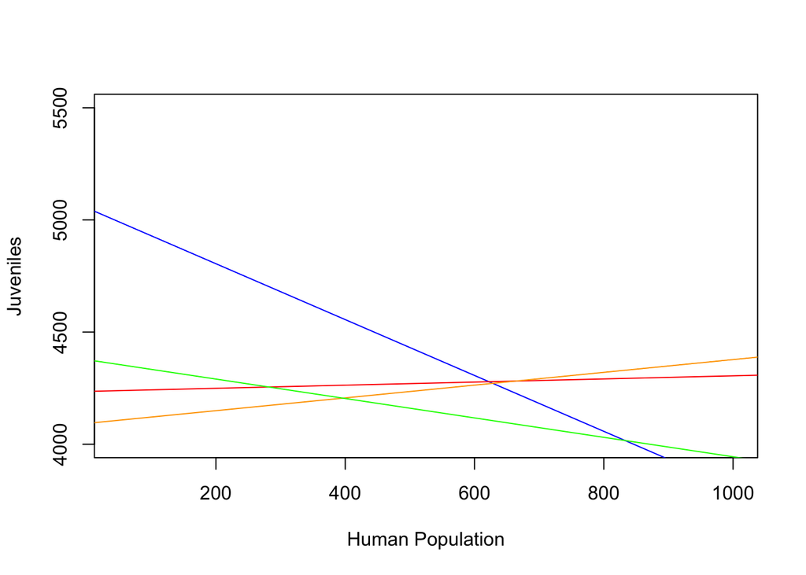

```r
plot(1:1000, rep(-100, 1000), ylim = c(4000, 5500), xlim = c(50, 1000), xlab = 'Human Population', ylab = 'Juveniles')
abline(a = 5054.11977, b = -1.24563, col = 'blue') # China
abline(a = 5054.11977 - 818.65030, b = -1.24563 + 1.31526, col = 'red') # India
abline(a = 5054.11977 - 961.39246 , b = -1.24563 + 1.53082, col = 'orange') # Indonesia
abline(a = 5054.11977 - 676.65413, b = -1.24563 + 0.81239, col = 'green') # Malaysia
```

# Exercise 5

**Please explain where I got the numbers to calculate the slopes for each country (what I put as the b value in each abline). This is how you interpret interaction terms! If any of the interaction terms were not significant, then we would have added 0 to the original slope of -1.24563, meaning there is no difference in the effect of human population on juvenile bird populations in that country.**

- The `a` term of the `abline()` function represents the y-intercept which should consider both the country-level and reference level which use the data of China. So for example, the y-intercept of countryIndia is `(Intercept) + countryIndia`$=5054.11977 + (-818.65030) = 5054.11977 - 818.65030$.
- The `b` term of the `abline()` function is the slope of the line. Because `humanpop` was interacted with `country`, the line representing the relationship of `humanpop` and `juveniles` now has both a different y-intercept and a different slope for every country. The main effect of `humanpop` is $-1.2456$. The country-specific effects of `humanpop` get their country-specific contrasts added to this main effect. For example, for India, it is `humanpop + humanpop:countryIndia`$=-1.2456 + 1.3153$. For China, because it is the reference level,its effect of `humanpop` as just the main effect of `humanpop`: $-1.2456$.